# Trabajo Práctico N° 2

Maestría en Econometría UTDT - Análisis Estadístico Multivariado

Juan Menduiña

# Ejercicio 1

*El archivo “ine.dta” es una base de datos que contiene los gastos promedio, en euros, de los hogares españoles, por grandes rubros y comunidad autónoma, correspondientes a los relevamientos de la encuesta de presupuestos familiares del año 2005 realizada por el Instituto Nacional de Estadísticas de España (INE). La descripción de las variables y de la base puede consultarse en las etiquetas asociadas a cada una.*

```r
ine <- as.data.frame(read_dta(file.path(datos, "ine.dta")))
vars1 <- c("alybnh", "vestcal", "vivagelo", "mobymant", "salud", "transp",
           "comu", "ocio", "educ", "esparc", "otros")
X1 <- ine[vars1]
cols1 <- length(vars1)
# Etiquetas de las variables
sapply(ine[vars1], function(x) attr(x, "label"))
```

```
##                                                                             alybnh
##                      "Gasto medio en alimentos y bebidas no alcoholicas, en euros"
##                                                                            vestcal
##                                     "Gasto medio en artículos de vestir y calzado"
##                                                                           vivagelo
##       "Gasto medio en vivienda, agua, electricidad y otros combustibles, en euros"
##                                                                           mobymant
## "Gasto medio en mobiliario, equipamiento del hogar y gastos corrientes de conserv"
##                                                                              salud
##                                                   "Gasto medio en salud, en euros"
##                                                                             transp
##                                              "Gasto medio en transporte, en euros"
##                                                                               comu
##                                                    "Gasto medio en comunicaciones"
##                                                                               ocio
##                            "Gasto medio en ocio, espectáculos y cultura, en euros"
##                                                                               educ
##                                               "Gasto medio en enseñanza, en euros"
##                                                                             esparc
##                           "Gasto medio en hoteles, cafés y restaurantes, en euros"
##                                                                              otros
##                                "Gasto medio en otros bienes y servicios, en euros"
```

## (a) Realizar un análisis descriptivo de los datos.

```r
descriptivo(X1)
```

**Resumen:**

|  | Obs | Media | Desv. est. | Mín | Máx |
| --- | --- | --- | --- | --- | --- |
| alybnh | 18 | 4200,5717 | 712,6440 | 3406,59 | 6561,27 |
| vestcal | 18 | 1751,3800 | 389,5767 | 1244,85 | 2792,25 |
| vivagelo | 18 | 7863,7573 | 1846,8332 | 4833,29 | 12291,94 |
| mobymant | 18 | 1131,0672 | 205,8000 | 724,82 | 1500,56 |
| salud | 18 | 570,0333 | 151,5053 | 302,85 | 942,22 |
| transp | 18 | 2561,3973 | 411,2195 | 1680,61 | 3148,50 |
| comu | 18 | 678,1139 | 97,7877 | 496,75 | 897,13 |
| ocio | 18 | 1485,0722 | 352,4416 | 746,21 | 2080,19 |
| educ | 18 | 231,9739 | 98,8610 | 87,76 | 438,92 |
| esparc | 18 | 2178,8017 | 349,0546 | 1670,36 | 2840,56 |
| otros | 18 | 1510,9611 | 263,4181 | 898,30 | 1925,89 |

**Media, varianza y coeficiente de variación:**

|  | alybnh | vestcal | vivagelo | mobymant | salud | transp | comu | ocio | educ | esparc | otros |
| --- | --- | --- | --- | --- | --- | --- | --- | --- | --- | --- | --- |
| Media | 4200,57174 | 1,75138e+03 | 7,863757e+03 | 1131,06723 | 570,03333 | 2561,39725 | 678,11389 | 1485,07222 | 231,97389 | 2178,8017 | 1510,96110 |
| Varianza | 507861,53134 | 1,51770e+05 | 3,410793e+06 | 42353,62250 | 22953,84729 | 169101,46671 | 9562,44069 | 124215,05988 | 9773,49118 | 121839,1158 | 69389,07825 |
| CV | 0,16965 | 2,22440e-01 | 2,348500e-01 | 0,18195 | 0,26578 | 0,16054 | 0,14421 | 0,23732 | 0,42617 | 0,1602 | 0,17434 |

**Matriz de correlaciones:**

|  | alybnh | vestcal | vivagelo | mobymant | salud | transp | comu | ocio | educ | esparc | otros |
| --- | --- | --- | --- | --- | --- | --- | --- | --- | --- | --- | --- |
| alybnh | 1,0000 | 0,8303 | 0,1151 | 0,4255 | 0,5876 | 0,1807 | 0,4905 | 0,3118 | 0,1116 | 0,3450 | 0,2994 |
| vestcal | 0,8303 | 1,0000 | 0,2817 | 0,5484 | 0,5515 | -0,0512 | 0,4005 | 0,4689 | 0,3366 | 0,4988 | 0,3766 |
| vivagelo | 0,1151 | 0,2817 | 1,0000 | 0,6729 | 0,3730 | 0,2390 | 0,6784 | 0,8845 | 0,8761 | 0,8082 | 0,5744 |
| mobymant | 0,4255 | 0,5484 | 0,6729 | 1,0000 | 0,4359 | 0,3747 | 0,7074 | 0,7746 | 0,6143 | 0,7159 | 0,6579 |
| salud | 0,5876 | 0,5515 | 0,3730 | 0,4359 | 1,0000 | 0,2431 | 0,6655 | 0,5416 | 0,3818 | 0,5586 | 0,2632 |
| transp | 0,1807 | -0,0512 | 0,2390 | 0,3747 | 0,2431 | 1,0000 | 0,5336 | 0,2545 | 0,1906 | 0,2354 | 0,4942 |
| comu | 0,4905 | 0,4005 | 0,6784 | 0,7074 | 0,6655 | 0,5336 | 1,0000 | 0,7954 | 0,6814 | 0,7587 | 0,6145 |
| ocio | 0,3118 | 0,4689 | 0,8845 | 0,7746 | 0,5416 | 0,2545 | 0,7954 | 1,0000 | 0,8939 | 0,8548 | 0,6348 |
| educ | 0,1116 | 0,3366 | 0,8761 | 0,6143 | 0,3818 | 0,1906 | 0,6814 | 0,8939 | 1,0000 | 0,7795 | 0,5729 |
| esparc | 0,3450 | 0,4988 | 0,8082 | 0,7159 | 0,5586 | 0,2354 | 0,7587 | 0,8548 | 0,7795 | 1,0000 | 0,4650 |
| otros | 0,2994 | 0,3766 | 0,5744 | 0,6579 | 0,2632 | 0,4942 | 0,6145 | 0,6348 | 0,5729 | 0,4650 | 1,0000 |

**Matriz de varianzas y covarianzas:**

|  | alybnh | vestcal | vivagelo | mobymant | salud | transp | comu | ocio | educ | esparc | otros |
| --- | --- | --- | --- | --- | --- | --- | --- | --- | --- | --- | --- |
| alybnh | 507861,5 | 230526,4 | 151455 | 62406 | 63440,3 | 52953,1 | 34183,7 | 78309 | 7865,8 | 85819 | 56211 |
| vestcal | 230526,4 | 151770,0 | 202659 | 43971 | 32552,6 | -8196,4 | 15255,9 | 64382 | 12962,6 | 67824 | 38643 |
| vivagelo | 151454,6 | 202658,7 | 3410793 | 255737 | 104374,9 | 181481,3 | 122513,3 | 575741 | 159963,6 | 520992 | 279426 |
| mobymant | 62406,2 | 43970,8 | 255737 | 42354 | 13591,6 | 31707,6 | 14235,9 | 56184 | 12497,5 | 51426 | 35665 |
| salud | 63440,3 | 32552,6 | 104375 | 13592 | 22953,8 | 15144,9 | 9859,8 | 28917 | 5719,0 | 29541 | 10505 |
| transp | 52953,1 | -8196,4 | 181481 | 31708 | 15144,9 | 169101,5 | 21457,3 | 36890 | 7749,1 | 33784 | 53537 |
| comu | 34183,7 | 15255,9 | 122513 | 14236 | 9859,8 | 21457,3 | 9562,4 | 27412 | 6587,3 | 25895 | 15828 |
| ocio | 78308,8 | 64381,6 | 575741 | 56184 | 28917,1 | 36890,3 | 27411,5 | 124215 | 31144,4 | 105165 | 58937 |
| educ | 7865,8 | 12962,6 | 159964 | 12498 | 5719,0 | 7749,1 | 6587,3 | 31144 | 9773,5 | 26898 | 14920 |
| esparc | 85819,1 | 67823,8 | 520992 | 51426 | 29541,2 | 33783,9 | 25895,3 | 105165 | 26897,8 | 121839 | 42757 |
| otros | 56211,0 | 38643,3 | 279426 | 35665 | 10505,0 | 53537,4 | 15828,2 | 58937 | 14920,0 | 42757 | 69389 |

**Correlaciones parcial y semiparcial de alybnh con las demás variables:**

|  | Corr. parcial | Corr. semiparcial | Corr. parcial^2 | Corr. semiparcial^2 | Valor p |
| --- | --- | --- | --- | --- | --- |
| vestcal | 0,8688 | 0,5915 | 0,7549 | 0,3498 | 0,0024 |
| vivagelo | 0,1226 | 0,0416 | 0,0150 | 0,0017 | 0,7534 |
| mobymant | -0,2715 | -0,0951 | 0,0737 | 0,0090 | 0,4798 |
| salud | -0,1229 | -0,0417 | 0,0151 | 0,0017 | 0,7528 |
| transp | 0,2801 | 0,0983 | 0,0785 | 0,0097 | 0,4654 |
| comu | 0,6013 | 0,2536 | 0,3615 | 0,0643 | 0,0868 |
| ocio | 0,0837 | 0,0283 | 0,0070 | 0,0008 | 0,8305 |
| educ | -0,4532 | -0,1714 | 0,2054 | 0,0294 | 0,2205 |
| esparc | -0,2692 | -0,0942 | 0,0725 | 0,0089 | 0,4837 |
| otros | -0,2278 | -0,0788 | 0,0519 | 0,0062 | 0,5556 |

## (b) Realizar un análisis de componentes principales.

**Basado en matriz de correlaciones:**

```r
pc1 <- pca_corr(X1, ref = c(1, 1, 1))   # alybnh con carga positiva en los 3 primeros
tabla(tabla_pca(pc1$ev), d = 4)
```

|  | Autovalor | Diferencia | Proporción | Acumulada |
| --- | --- | --- | --- | --- |
| Comp1 | 6,3180 | 4,6345 | 0,5744 | 0,5744 |
| Comp2 | 1,6835 | 0,5189 | 0,1530 | 0,7274 |
| Comp3 | 1,1646 | 0,4527 | 0,1059 | 0,8333 |
| Comp4 | 0,7119 | 0,3762 | 0,0647 | 0,8980 |
| Comp5 | 0,3357 | 0,0889 | 0,0305 | 0,9285 |
| Comp6 | 0,2469 | 0,0687 | 0,0224 | 0,9510 |
| Comp7 | 0,1782 | 0,0371 | 0,0162 | 0,9672 |
| Comp8 | 0,1411 | 0,0156 | 0,0128 | 0,9800 |
| Comp9 | 0,1255 | 0,0651 | 0,0114 | 0,9914 |
| Comp10 | 0,0604 | 0,0262 | 0,0055 | 0,9969 |
| Comp11 | 0,0342 | NA | 0,0031 | 1,0000 |

```r
tabla(pc1$V, d = 4)
```

|  | Comp1 | Comp2 | Comp3 | Comp4 | Comp5 | Comp6 | Comp7 | Comp8 | Comp9 | Comp10 | Comp11 |
| --- | --- | --- | --- | --- | --- | --- | --- | --- | --- | --- | --- |
| alybnh | 0,2073 | 0,6146 | 0,1074 | 0,0974 | -0,0291 | 0,4075 | 0,2469 | -0,1482 | -0,2589 | -0,1293 | -0,4740 |
| vestcal | 0,2441 | 0,5185 | -0,2140 | 0,3225 | 0,0077 | 0,1046 | -0,3670 | -0,0381 | 0,1907 | 0,1589 | 0,5595 |
| vivagelo | 0,3315 | -0,3155 | -0,2008 | -0,0142 | -0,0053 | 0,1415 | -0,1154 | -0,1745 | -0,7708 | 0,2617 | 0,1536 |
| mobymant | 0,3387 | -0,0037 | 0,0613 | 0,2925 | -0,5949 | -0,5657 | 0,1077 | -0,2229 | 0,0724 | 0,1447 | -0,1859 |
| salud | 0,2635 | 0,3311 | 0,0166 | -0,6080 | 0,3392 | -0,5052 | -0,2374 | -0,0221 | -0,0754 | 0,0557 | -0,1226 |
| transp | 0,1628 | -0,1258 | 0,7924 | -0,1381 | -0,1746 | 0,2416 | -0,4188 | -0,1691 | 0,0608 | -0,0674 | 0,0976 |
| comu | 0,3549 | -0,0061 | 0,2045 | -0,2695 | 0,0288 | 0,1126 | 0,6905 | 0,1208 | 0,1672 | 0,2743 | 0,3892 |
| ocio | 0,3716 | -0,1529 | -0,1714 | -0,0178 | 0,0565 | -0,0395 | 0,0991 | -0,2073 | 0,0471 | -0,8409 | 0,2046 |
| educ | 0,3285 | -0,2921 | -0,2482 | -0,0056 | 0,2639 | 0,2693 | -0,1127 | -0,3735 | 0,4946 | 0,2721 | -0,3634 |
| esparc | 0,3507 | -0,0735 | -0,2080 | -0,1840 | -0,3619 | 0,2056 | -0,2194 | 0,7228 | 0,0861 | -0,0665 | -0,1970 |
| otros | 0,2863 | -0,1195 | 0,3072 | 0,5524 | 0,5432 | -0,2004 | 0,0105 | 0,3845 | -0,0748 | -0,0081 | -0,1241 |

**Basado en matriz de varianzas y covarianzas:**

```r
pc1_cov <- pca_cov(X1)
tabla_cient(as.matrix(tabla_pca(pc1_cov$ev)), d = 4)
```

|  | Autovalor | Diferencia | Proporción | Acumulada |
| --- | --- | --- | --- | --- |
| Comp1 | 3687478 | 3054179,8 | 0,7947814 | 0,7948 |
| Comp2 | 633298 | 456209,9 | 0,1364980 | 0,9313 |
| Comp3 | 177088 | 130083,4 | 0,0381687 | 0,9694 |
| Comp4 | 47005 | 5090,2 | 0,0101312 | 0,9796 |
| Comp5 | 41915 | 23807,5 | 0,0090341 | 0,9886 |
| Comp6 | 18107 | 5406,3 | 0,0039027 | 0,9925 |
| Comp7 | 12701 | 510,3 | 0,0027374 | 0,9953 |
| Comp8 | 12190 | 4653,0 | 0,0026274 | 0,9979 |
| Comp9 | 7537 | 6015,2 | 0,0016246 | 0,9995 |
| Comp10 | 1522 | 750,2 | 0,0003281 | 0,9998 |
| Comp11 | 772 | NA | 0,0001664 | 1,0000 |

```r
tabla(pc1_cov$V, d = 4)
```

|  | Comp1 | Comp2 | Comp3 | Comp4 | Comp5 | Comp6 | Comp7 | Comp8 | Comp9 | Comp10 | Comp11 |
| --- | --- | --- | --- | --- | --- | --- | --- | --- | --- | --- | --- |
| alybnh | 0,0638 | 0,8748 | 0,0036 | -0,3835 | -0,0667 | 0,1843 | -0,1913 | -0,0431 | -0,0210 | -0,0181 | 0,0771 |
| vestcal | 0,0674 | 0,4068 | -0,2632 | 0,4366 | -0,1017 | -0,5842 | 0,4014 | 0,1016 | -0,1445 | 0,0458 | -0,1550 |
| vivagelo | 0,9596 | -0,1403 | -0,0612 | -0,1929 | -0,1053 | -0,0776 | 0,0174 | 0,0039 | 0,0315 | -0,0062 | -0,0122 |
| mobymant | 0,0756 | 0,0907 | 0,0793 | 0,3368 | 0,0122 | -0,0716 | -0,1282 | -0,8100 | 0,4121 | 0,0663 | 0,1192 |
| salud | 0,0325 | 0,1034 | 0,0181 | -0,0021 | 0,2610 | 0,2465 | 0,5642 | 0,2636 | 0,6688 | -0,0669 | 0,1393 |
| transp | 0,0559 | 0,0724 | 0,9261 | -0,0395 | 0,1198 | -0,2521 | 0,1785 | 0,0056 | -0,1481 | -0,0271 | -0,0018 |
| comu | 0,0363 | 0,0463 | 0,0764 | 0,0249 | 0,0980 | 0,2043 | -0,0221 | 0,0149 | 0,1007 | 0,6585 | -0,7031 |
| ocio | 0,1662 | 0,0812 | 0,0016 | 0,3749 | 0,1859 | 0,6086 | 0,2876 | -0,1949 | -0,4906 | -0,2321 | -0,0707 |
| educ | 0,0455 | -0,0020 | -0,0093 | 0,0953 | 0,0272 | 0,0785 | 0,0867 | 0,0706 | -0,2086 | 0,7023 | 0,6578 |
| esparc | 0,1514 | 0,1031 | -0,0276 | 0,3115 | 0,7140 | -0,1199 | -0,5073 | 0,2790 | 0,0444 | -0,0676 | 0,0522 |
| otros | 0,0823 | 0,0777 | 0,2368 | 0,5126 | -0,5803 | 0,2381 | -0,2953 | 0,3757 | 0,2055 | -0,0525 | 0,0391 |

## (c) Efectuar la selección de los componentes principales de acuerdo con los siguientes modos:

### (i) Búsqueda del “codo”.

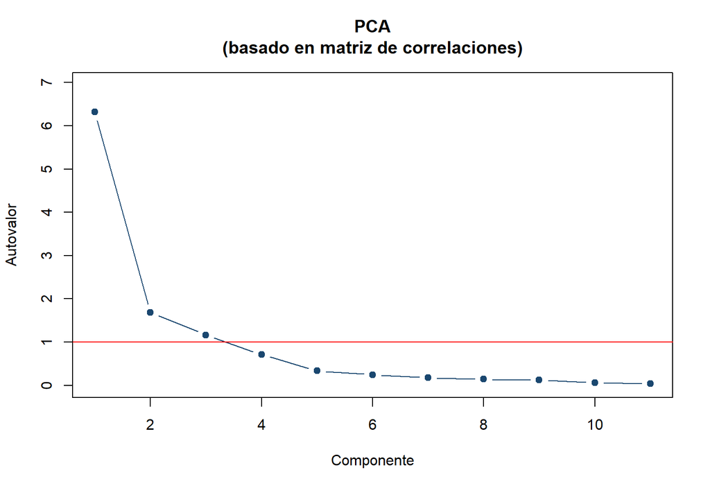

```r
screeplot_r(pc1$ev)
```

Mediante este modo, se seleccionarían los tres primeros componentes principales.

### (ii) Búsqueda por umbral de varianza a explicar, considerando un 80%.

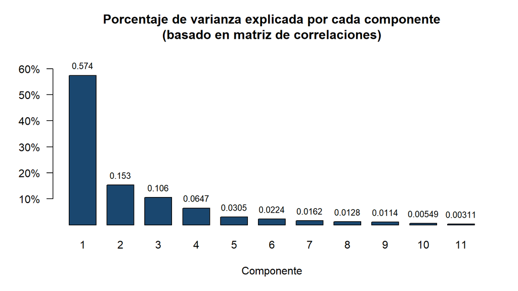

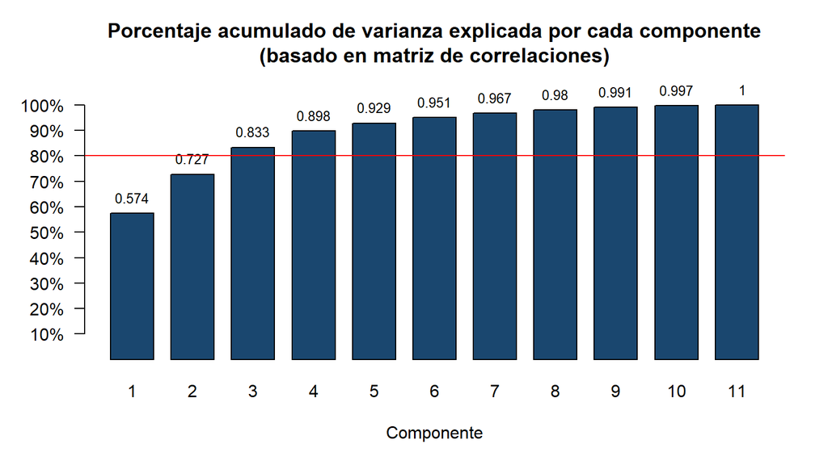

```r
barras_prop(pc1$ev, umbral = 0.8)
```

Mediante este modo, se seleccionarían los tres primeros componentes principales (que explican, en conjunto, 83,33% de la varianza).

### (iii) Búsqueda por tope mínimo al valor de los eigenvalores, considerando la varianza media.

```r
varianza_media1 <- mean(pc1$ev)
varianza_media1
```

```
## [1] 1
```

```r
which(pc1$ev > varianza_media1)
```

```
## [1] 1 2 3
```

Mediante este modo, se seleccionarían los tres primeros componentes principales, ya que estos tienen un autovalor mayor a 1, correspondiente a la varianza media.

## (d) Interpretar los componentes seleccionados. Para ello, se puede emplear el archivo “renta.csv”. Aclaración: El archivo “renta.csv” contiene información referida al ingreso promedio por hogar, por comunidad; relevado por el INE para el año 2005.

Componentes retenidos (tres primeros) y varianza no explicada de cada variable:

```r
tabla(cbind(pc1$V[, 1:3], `No explicada` = sin_explicar(pc1, 3)), d = 4)
```

|  | Comp1 | Comp2 | Comp3 | No explicada |
| --- | --- | --- | --- | --- |
| alybnh | 0,2073 | 0,6146 | 0,1074 | 0,0791 |
| vestcal | 0,2441 | 0,5185 | -0,2140 | 0,1178 |
| vivagelo | 0,3315 | -0,3155 | -0,2008 | 0,0913 |
| mobymant | 0,3387 | -0,0037 | 0,0613 | 0,2709 |
| salud | 0,2635 | 0,3311 | 0,0166 | 0,3763 |
| transp | 0,1628 | -0,1258 | 0,7924 | 0,0746 |
| comu | 0,3549 | -0,0061 | 0,2045 | 0,1554 |
| ocio | 0,3716 | -0,1529 | -0,1714 | 0,0540 |
| educ | 0,3285 | -0,2921 | -0,2482 | 0,1030 |
| esparc | 0,3507 | -0,0735 | -0,2080 | 0,1633 |
| otros | 0,2863 | -0,1195 | 0,3072 | 0,3483 |

El primer autovector pondera con signo positivo a todas las variables, por lo que el primer componente puede ser interpretado como una medida global de gasto.

El segundo autovector pondera con un signo positivo a la primera, segunda y quinta variable y con signo negativo a las restantes, por lo que el segundo componente tomará valores altos en aquellas comunidades cuyos gastos de necesidad primaria (alimentos y bebidas no alcohólicas, artículos de vestir y calzado, y salud) resulten más importantes, en términos relativos, a los restantes.

El tercer autovector pondera con un signo negativo a la segunda, tercera, octava, novena y décima variable y con signo positivo a las restantes, por lo que el tercer componente tomará valores altos en aquellas comunidades cuyos gastos en transporte, en comunicaciones y otros resulten más importantes, en términos relativos, a los restantes.

Como apoyo, se pueden relacionar los componentes con el ingreso medio por hogar de cada comunidad (`renta.csv`):

```r
renta <- read.csv2(file.path(datos, "renta.csv"), fileEncoding = "latin1",
                   strip.white = TRUE, stringsAsFactors = FALSE)
names(renta) <- trimws(names(renta))
renta$comunidad <- trimws(renta$comunidad)
idx <- match(trimws(ine$comunidad), renta$comunidad)
stopifnot(!anyNA(idx))   # todas las comunidades se emparejan por nombre
imedhog <- renta$imedhog[idx]

sc1 <- scores_pca(X1, pc1)[, 1:3]
tabla(data.frame(Componente = paste0("Comp", 1:3),
                 `Correlación con la renta media` = as.vector(cor(sc1, imedhog)),
                 check.names = FALSE), d = 4)
```

| Componente | Correlación con la renta media |
| --- | --- |
| Comp1 | 0,7360 |
| Comp2 | -0,1628 |
| Comp3 | -0,2905 |

# Ejercicio 2

*En relación al ejercicio anterior, realizar el biplot asociado a las dos dimensiones principales, considerando un parámetro c = 0,5.*

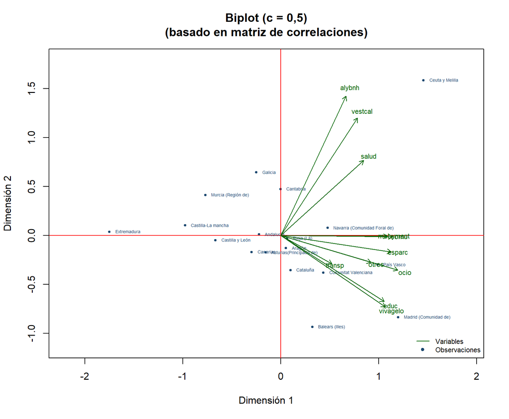

```r
biplot_r(X1, pc1, c = 0.5, dx = 1, dy = 2, etiquetas = ine$comunidad)
```

# Ejercicio 3

*Teniendo en cuenta la misma base de datos del primer punto, efectuar los biplots correspondientes a las dos dimensiones principales y a la primera y tercera, considerando, en ambos casos, un parámetro c = 0. Comentar, brevemente, el resultado en relación a lo obtenido mediante el análisis de componentes principales efectuado en el primer ejercicio.*

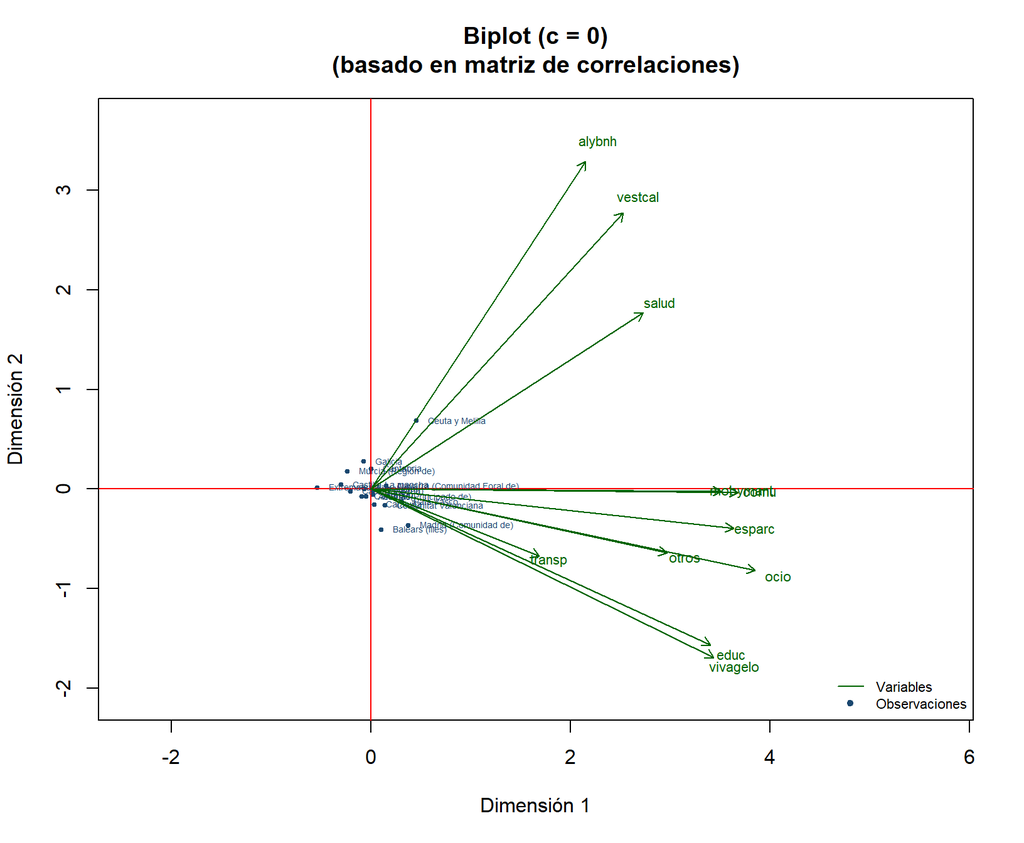

```r
biplot_r(X1, pc1, c = 0, dx = 1, dy = 2, etiquetas = ine$comunidad)
```

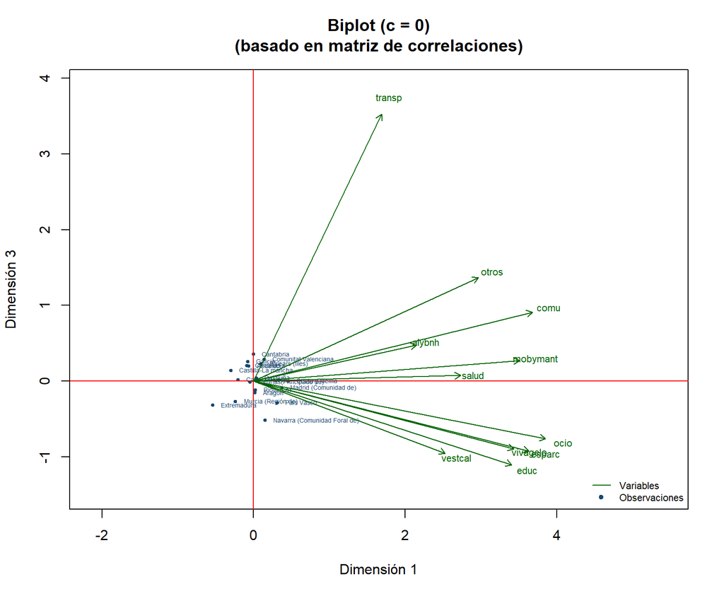

```r
biplot_r(X1, pc1, c = 0, dx = 1, dy = 3, etiquetas = ine$comunidad)
```

**Comentario.** Con c = 0, las variables se representan con $V D$ y las observaciones con $U$: la longitud de cada flecha aproxima la desviación estándar de la variable estandarizada y el ángulo entre dos flechas aproxima su correlación, mientras que las comunidades se ubican cerca del origen y su posición relativa refleja los valores de los componentes. El resultado es coherente con el análisis de componentes principales del Ejercicio 1:

- Sobre la dimensión 1, casi todas las flechas apuntan hacia la derecha, de modo que esta dimensión es una medida global de gasto: las comunidades hacia la derecha son las de mayor gasto general.
- En el plano de las dimensiones 1 y 2, las variables de necesidad primaria (`alybnh`, `vestcal` y `salud`) apuntan hacia arriba, y `vivagelo`, `educ` y `ocio`, hacia abajo, que es el contraste que se había identificado para el segundo componente.
- En el plano de las dimensiones 1 y 3, `transp` apunta marcadamente hacia arriba (con `otros` y `comu` en menor medida), que es lo que caracteriza al tercer componente.

# Ejercicio 4

*La base “wb.dta” contiene información relevada por el Banco Mundial en 77 países durante el año 2007 (los detalles de las variables relevadas se pueden observar en las etiquetas asignadas a las mismas). A partir de estos datos, se pide:*

```r
wb <- as.data.frame(read_dta(file.path(datos, "wb.dta")))
vars4 <- paste0("var", 4:12)
X4 <- wb[vars4]
cols4 <- length(vars4)
data.frame(variable = vars4, etiqueta = sapply(wb[vars4], function(x) attr(x, "label")))
```

|  | variable | etiqueta |
| --- | --- | --- |
| var4 | var4 | GNI per capita |
| var5 | var5 | Land under cereal production |
| var6 | var6 | Real Interest Rate |
| var7 | var7 | Life Expectancy at birth |
| var8 | var8 | Population |
| var9 | var9 | Fertility Rate |
| var10 | var10 | Internet Users |
| var11 | var11 | Labor Force |
| var12 | var12 | MFN Tariff Rate |

## (a) Realizar un análisis normado de componentes principales a partir de los datos.

```r
descriptivo(X4)
```

**Resumen:**

|  | Obs | Media | Desv. est. | Mín | Máx |
| --- | --- | --- | --- | --- | --- |
| var4 | 77 | 1,162506e+04 | 1,605777e+04 | 120,0000 | 7,725000e+04 |
| var5 | 77 | 4,777124e+06 | 1,309931e+07 | 108,0000 | 8,606047e+07 |
| var6 | 77 | 5,740400e+00 | 6,782000e+00 | -7,8027 | 3,854600e+01 |
| var7 | 77 | 7,012970e+01 | 9,854000e+00 | 43,5860 | 8,250710e+01 |
| var8 | 77 | 4,827885e+07 | 1,568382e+08 | 109005,0000 | 1,317885e+09 |
| var9 | 77 | 2,604900e+00 | 1,276100e+00 | 1,2090 | 6,711000e+00 |
| var10 | 77 | 1,241235e+07 | 3,671119e+07 | 16000,0000 | 2,217240e+08 |
| var11 | 77 | 2,475709e+07 | 9,049555e+07 | 52995,9336 | 7,710789e+08 |
| var12 | 77 | 6,968600e+00 | 4,106900e+00 | 1,1000 | 1,755000e+01 |

**Media, varianza y coeficiente de variación:**

|  | var4 | var5 | var6 | var7 | var8 | var9 | var10 | var11 | var12 |
| --- | --- | --- | --- | --- | --- | --- | --- | --- | --- |
| Media | 1,162506e+04 | 4,777124e+06 | 5,74042 | 70,12972 | 4,827885e+07 | 2,60486 | 1,241235e+07 | 2,475709e+07 | 6,96857 |
| Varianza | 2,578519e+08 | 1,715919e+14 | 45,99532 | 97,10075 | 2,459822e+16 | 1,62845 | 1,347712e+15 | 8,189445e+15 | 16,86665 |
| CV | 1,381310e+00 | 2,742090e+00 | 1,18144 | 0,14051 | 3,248590e+00 | 0,48989 | 2,957630e+00 | 3,655340e+00 | 0,58935 |

**Matriz de correlaciones:**

|  | var4 | var5 | var6 | var7 | var8 | var9 | var10 | var11 | var12 |
| --- | --- | --- | --- | --- | --- | --- | --- | --- | --- |
| var4 | 1,0000 | 0,0801 | -0,2190 | 0,5636 | -0,0296 | -0,4269 | 0,2510 | -0,0258 | -0,4814 |
| var5 | 0,0801 | 1,0000 | -0,0874 | 0,0888 | 0,8712 | -0,1313 | 0,8765 | 0,8604 | -0,0831 |
| var6 | -0,2190 | -0,0874 | 1,0000 | -0,2651 | -0,0627 | 0,3754 | -0,0395 | -0,0654 | 0,2313 |
| var7 | 0,5636 | 0,0888 | -0,2651 | 1,0000 | 0,0535 | -0,7897 | 0,2014 | 0,0578 | -0,4697 |
| var8 | -0,0296 | 0,8712 | -0,0627 | 0,0535 | 1,0000 | -0,0935 | 0,7932 | 0,9977 | -0,0541 |
| var9 | -0,4269 | -0,1313 | 0,3754 | -0,7897 | -0,0935 | 1,0000 | -0,1894 | -0,1017 | 0,4460 |
| var10 | 0,2510 | 0,8765 | -0,0395 | 0,2014 | 0,7932 | -0,1894 | 1,0000 | 0,7842 | -0,1683 |
| var11 | -0,0258 | 0,8604 | -0,0654 | 0,0578 | 0,9977 | -0,1017 | 0,7842 | 1,0000 | -0,0656 |
| var12 | -0,4814 | -0,0831 | 0,2313 | -0,4697 | -0,0541 | 0,4460 | -0,1683 | -0,0656 | 1,0000 |

**Matriz de varianzas y covarianzas:**

|  | var4 | var5 | var6 | var7 | var8 | var9 | var10 | var11 | var12 |
| --- | --- | --- | --- | --- | --- | --- | --- | --- | --- |
| var4 | 2,5785e+08 | 1,6845e+10 | -2,3848e+04 | 8,9187e+04 | -7,4616e+10 | -8,7469e+03 | 1,4798e+11 | -3,7509e+10 | -3,1747e+04 |
| var5 | 1,6845e+10 | 1,7159e+14 | -7,7676e+06 | 1,1463e+07 | 1,7898e+15 | -2,1951e+06 | 4,2152e+14 | 1,0199e+15 | -4,4681e+06 |
| var6 | -2,3848e+04 | -7,7676e+06 | 4,5995e+01 | -1,7718e+01 | -6,6711e+07 | 3,2487e+00 | -9,8373e+06 | -4,0130e+07 | 6,4415e+00 |
| var7 | 8,9187e+04 | 1,1463e+07 | -1,7718e+01 | 9,7101e+01 | 8,2613e+07 | -9,9301e+00 | 7,2853e+07 | 5,1561e+07 | -1,9009e+01 |
| var8 | -7,4616e+10 | 1,7898e+15 | -6,6711e+07 | 8,2613e+07 | 2,4598e+16 | -1,8718e+07 | 4,5673e+15 | 1,4160e+16 | -3,4839e+07 |
| var9 | -8,7469e+03 | -2,1951e+06 | 3,2487e+00 | -9,9301e+00 | -1,8718e+07 | 1,6284e+00 | -8,8741e+06 | -1,1743e+07 | 2,3372e+00 |
| var10 | 1,4798e+11 | 4,2152e+14 | -9,8373e+06 | 7,2853e+07 | 4,5673e+15 | -8,8741e+06 | 1,3477e+15 | 2,6052e+15 | -2,5380e+07 |
| var11 | -3,7509e+10 | 1,0199e+15 | -4,0130e+07 | 5,1561e+07 | 1,4160e+16 | -1,1743e+07 | 2,6052e+15 | 8,1894e+15 | -2,4376e+07 |
| var12 | -3,1747e+04 | -4,4681e+06 | 6,4415e+00 | -1,9009e+01 | -3,4839e+07 | 2,3372e+00 | -2,5380e+07 | -2,4376e+07 | 1,6867e+01 |

**Correlaciones parcial y semiparcial de var4 con las demás variables:**

|  | Corr. parcial | Corr. semiparcial | Corr. parcial^2 | Corr. semiparcial^2 | Valor p |
| --- | --- | --- | --- | --- | --- |
| var5 | -0,0356 | -0,0257 | 0,0013 | 0,0007 | 0,7697 |
| var6 | -0,1320 | -0,0959 | 0,0174 | 0,0092 | 0,2761 |
| var7 | 0,3341 | 0,2554 | 0,1116 | 0,0652 | 0,0047 |
| var8 | -0,0973 | -0,0704 | 0,0095 | 0,0050 | 0,4230 |
| var9 | 0,0990 | 0,0717 | 0,0098 | 0,0051 | 0,4150 |
| var10 | 0,3322 | 0,2538 | 0,1104 | 0,0644 | 0,0050 |
| var11 | 0,0618 | 0,0446 | 0,0038 | 0,0020 | 0,6113 |
| var12 | -0,2667 | -0,1993 | 0,0711 | 0,0397 | 0,0256 |

**Basado en matriz de correlaciones:**

```r
pc4 <- pca_corr(X4, ref = c(2, 6, 1))   # var5, var9 y var4 con carga positiva en los 3 primeros
tabla(tabla_pca(pc4$ev), d = 4)
```

|  | Autovalor | Diferencia | Proporción | Acumulada |
| --- | --- | --- | --- | --- |
| Comp1 | 3,7662 | 1,1397 | 0,4185 | 0,4185 |
| Comp2 | 2,6265 | 1,7429 | 0,2918 | 0,7103 |
| Comp3 | 0,8836 | 0,2177 | 0,0982 | 0,8085 |
| Comp4 | 0,6659 | 0,1156 | 0,0740 | 0,8825 |
| Comp5 | 0,5503 | 0,3194 | 0,0611 | 0,9436 |
| Comp6 | 0,2309 | 0,0525 | 0,0257 | 0,9693 |
| Comp7 | 0,1784 | 0,0822 | 0,0198 | 0,9891 |
| Comp8 | 0,0962 | 0,0942 | 0,0107 | 0,9998 |
| Comp9 | 0,0020 | NA | 0,0002 | 1,0000 |

```r
tabla(pc4$V, d = 4)
```

|  | Comp1 | Comp2 | Comp3 | Comp4 | Comp5 | Comp6 | Comp7 | Comp8 | Comp9 |
| --- | --- | --- | --- | --- | --- | --- | --- | --- | --- |
| var4 | 0,1573 | -0,4207 | 0,3471 | -0,3706 | 0,6232 | 0,2654 | 0,2748 | 0,0780 | 0,0050 |
| var5 | 0,4636 | 0,1900 | -0,0045 | -0,0344 | 0,0836 | -0,3818 | -0,0536 | 0,7690 | -0,0276 |
| var6 | -0,1164 | 0,2650 | 0,8765 | 0,3210 | -0,1591 | 0,0165 | 0,1262 | 0,0585 | 0,0016 |
| var7 | 0,1984 | -0,4836 | 0,1023 | 0,4485 | 0,0303 | 0,2174 | -0,6789 | 0,0775 | -0,0077 |
| var8 | 0,4593 | 0,2387 | -0,0633 | 0,0394 | -0,1126 | 0,4218 | 0,0934 | -0,0804 | 0,7216 |
| var9 | -0,2097 | 0,4571 | 0,1307 | -0,5155 | 0,1469 | 0,2391 | -0,6188 | 0,0504 | -0,0093 |
| var10 | 0,4634 | 0,1062 | 0,1710 | -0,0692 | 0,2079 | -0,5361 | -0,1922 | -0,6102 | -0,0086 |
| var11 | 0,4583 | 0,2327 | -0,0641 | 0,0375 | -0,1291 | 0,4577 | 0,1196 | -0,1077 | -0,6916 |
| var12 | -0,1666 | 0,3892 | -0,2151 | 0,5327 | 0,6959 | 0,0654 | 0,0441 | -0,0136 | -0,0075 |

**Basado en matriz de varianzas y covarianzas:**

```r
pc4_cov <- pca_cov(X4)
tabla_cient(as.matrix(tabla_pca(pc4_cov$ev)), d = 4)
```

|  | Autovalor | Diferencia | Proporción | Acumulada |
| --- | --- | --- | --- | --- |
| Comp1 | 3,375e+16 | 3,324e+16 | 9,837e-01 | 0,9837 |
| Comp2 | 5,075e+14 | 4,757e+14 | 1,479e-02 | 0,9985 |
| Comp3 | 3,184e+13 | 1,135e+13 | 9,280e-04 | 0,9994 |
| Comp4 | 2,049e+13 | 2,049e+13 | 5,972e-04 | 1,0000 |
| Comp5 | 1,997e+08 | 1,997e+08 | 5,822e-09 | 1,0000 |
| Comp6 | 6,894e+01 | 3,092e+01 | 2,010e-15 | 1,0000 |
| Comp7 | 3,802e+01 | 2,498e+01 | 1,108e-15 | 1,0000 |
| Comp8 | 1,304e+01 | 1,235e+01 | 3,801e-16 | 1,0000 |
| Comp9 | 6,841e-01 | NA | 1,994e-17 | 1,0000 |

```r
tabla(pc4_cov$V, d = 4)
```

|  | Comp1 | Comp2 | Comp3 | Comp4 | Comp5 | Comp6 | Comp7 | Comp8 | Comp9 |
| --- | --- | --- | --- | --- | --- | --- | --- | --- | --- |
| var4 | 0,0000 | 0,0003 | -0,0005 | 0,0001 | 1e+00 | -0,0004 | 0,0000 | 0,0000 | 0,0000 |
| var5 | 0,0625 | 0,1785 | 0,5969 | 0,7797 | 2e-04 | 0,0000 | 0,0000 | 0,0000 | 0,0000 |
| var6 | 0,0000 | 0,0000 | 0,0000 | 0,0000 | -1e-04 | -0,3273 | 0,9413 | -0,0730 | -0,0395 |
| var7 | 0,0000 | 0,0000 | 0,0000 | 0,0000 | 3e-04 | 0,8879 | 0,3362 | 0,2927 | 0,1142 |
| var8 | 0,8535 | -0,1211 | 0,3820 | -0,3331 | 2e-04 | 0,0000 | 0,0000 | 0,0000 | 0,0000 |
| var9 | 0,0000 | 0,0000 | 0,0000 | 0,0000 | 0e+00 | -0,0869 | 0,0016 | -0,1240 | 0,9885 |
| var10 | 0,1607 | 0,9679 | -0,1538 | -0,1167 | -4e-04 | 0,0000 | 0,0000 | 0,0000 | 0,0000 |
| var11 | 0,4917 | -0,1287 | -0,6886 | 0,5172 | -3e-04 | 0,0000 | 0,0000 | 0,0000 | 0,0000 |
| var12 | 0,0000 | 0,0000 | 0,0000 | 0,0000 | -1e-04 | -0,3115 | -0,0312 | 0,9453 | 0,0912 |

> **⚠ Anotación (diferencia de salida respecto del PDF):** la tabla de Stata del PDF muestra solo 4 componentes con autovalor distinto de cero en el análisis sobre covarianzas (los componentes 5 a 9 figuran como 0). En R se calculan los 9 autovalores: los componentes 5 a 9 no son exactamente cero, pero en conjunto representan apenas 5,82e-07% de la varianza total, por lo que la conclusión es la misma.

Como las variables están medidas en unidades muy distintas (población y fuerza laboral en millones de personas frente a tasas porcentuales), el análisis sobre la matriz de covarianzas queda dominado por las variables de mayor escala (`var8`, `var11`, `var10` y `var5`); por eso se trabaja con la matriz de correlaciones.

## (b) ¿Cuántos componentes se sugiere extraer?

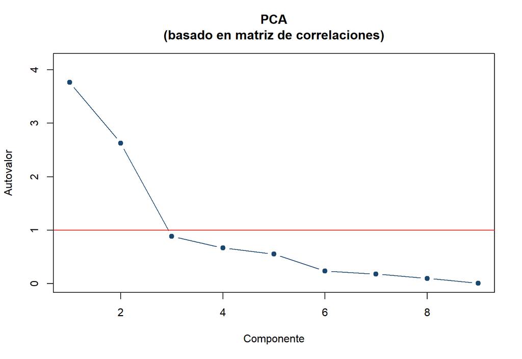

```r
screeplot_r(pc4$ev)
```

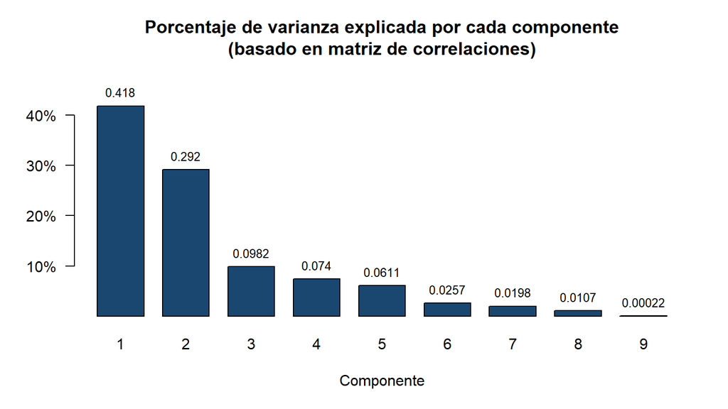

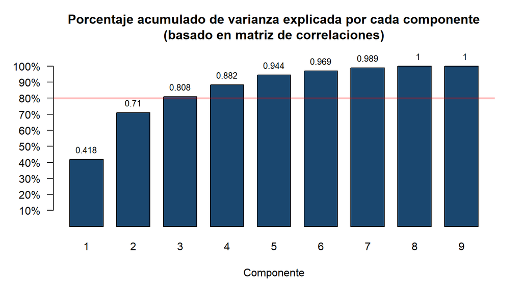

```r
barras_prop(pc4$ev, umbral = 0.8)
```

Por lo tanto, se sugiere extraer los tres primeros componentes principales: el “codo” aparece en el tercer componente y, con los dos primeros, se explica 71,03% de la varianza, por lo que el tercer componente es necesario para superar el umbral del 80%.

## (c) ¿Cuál es el porcentaje de variabilidad total explicado por las componentes seleccionadas?

```r
pct4 <- 100 * sum(pc4$ev[1:3]) / sum(pc4$ev)
```

El porcentaje de variabilidad total explicado por las componentes seleccionadas es 80,85%.

## (d) ¿Qué interpretación se sugiere de las componentes, con arreglo a las correlaciones existentes con las variables originales? Para este punto, se puede ayudar con la estructura de análisis presente en el libro “P2.xlsx”.

Correlaciones entre cada componente y las variables originales (cargas por la raíz del autovalor):

```r
cor_comp4 <- sweep(pc4$V[, 1:3], 2, sqrt(pc4$ev[1:3]), "*")
tabla(cbind(`Etiqueta` = sapply(wb[vars4], function(x) attr(x, "label")),
            as.data.frame(round(cor_comp4, 4))), d = 4)
```

|  | Etiqueta | Comp1 | Comp2 | Comp3 |
| --- | --- | --- | --- | --- |
| var4 | GNI per capita | 0,3052 | -0,6818 | 0,3263 |
| var5 | Land under cereal production | 0,8997 | 0,3080 | -0,0043 |
| var6 | Real Interest Rate | -0,2258 | 0,4294 | 0,8239 |
| var7 | Life Expectancy at birth | 0,3850 | -0,7838 | 0,0961 |
| var8 | Population | 0,8914 | 0,3868 | -0,0595 |
| var9 | Fertility Rate | -0,4069 | 0,7408 | 0,1228 |
| var10 | Internet Users | 0,8993 | 0,1722 | 0,1607 |
| var11 | Labor Force | 0,8894 | 0,3771 | -0,0602 |
| var12 | MFN Tariff Rate | -0,3232 | 0,6307 | -0,2022 |

El segundo autovector pondera con signo positivo a todas las variables excepto a “GNI per cápita” y “Life Expectancy at Birth”, por lo que el segundo componente principal tomará valores bajos en aquellos países cuyos valores en estas variables resulten más importantes, en términos relativos, a los restantes.

## (e) Clasificar a los países de acuerdo con las dos componentes principales.

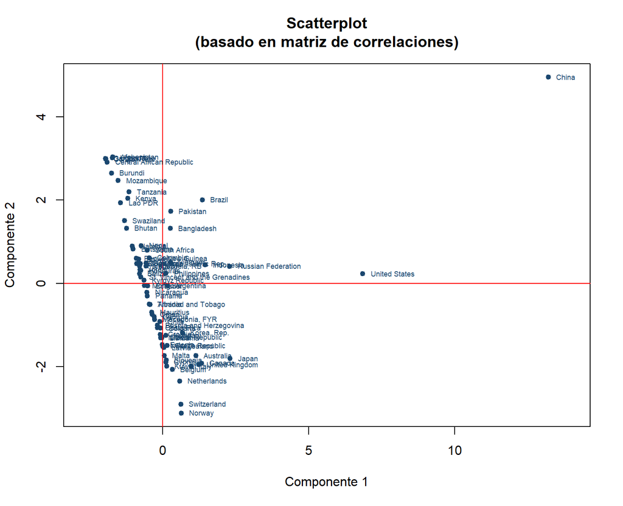

```r
sc4 <- scores_pca(X4, pc4)
scatter_pca(sc4, wb$var1, cex_lab = 0.55)
```

## (f) Realice un biplot considerando las dos dimensiones principales de análisis para un parámetro c = 0.5. ¿Qué se puede decir sobre la posición de los Estados Unidos y China y su influencia en el análisis, a la luz de los resultados obtenidos?

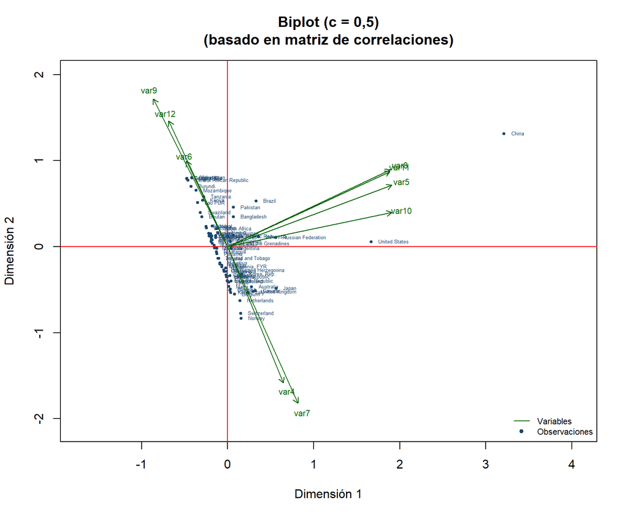

```r
biplot_r(X4, pc4, c = 0.5, dx = 1, dy = 2, etiquetas = wb$var1, cex_obs = 0.4)
```

# Ejercicio 5

*La base “hspendusa2009.csv” contiene información relevada durante los años 2008-2009 por el Instituto de Estadísticas de los Estados Unidos, correspondiente a los gastos medios de los hogares por capítulos y por área metropolitana (los detalles de las variables se pueden observar en el archivo “usa.xlsx”). Efectuar un análisis de componentes principales.*

```r
usa <- read.csv(file.path(datos, "hspendusa2009.csv"), stringsAsFactors = FALSE)
usa$meta <- trimws(usa$meta)
vars5 <- paste0("s", 1:12)
X5 <- usa[vars5]
cols5 <- length(vars5)
str(usa)
```

```
## 'data.frame':    18 obs. of  13 variables:
##  $ meta: chr  "Atlanta, Georgia MSA" "Baltimore, Maryland MSA" "Boston-Lawrence-Salem, Massachusetts-New Hampshire CMSA" "Chicago-Gary-Lake County, Illinois-Indiana-Wisconsin CMSA" ...
##  $ s1  : int  2717 3300 4905 4250 3642 3600 3944 3649 4260 3741 ...
##  $ s2  : int  324 353 641 510 424 408 367 710 504 349 ...
##  $ s3  : int  17072 20795 20802 20620 15483 18198 16344 18866 21811 19016 ...
##  $ s4  : int  1580 1511 1910 2206 1550 2161 1678 2256 2140 1677 ...
##  $ s5  : int  6760 6621 8591 8840 7010 8689 9463 10843 8784 8427 ...
##  $ s6  : int  2417 2973 3453 3485 3315 3032 2672 3267 2620 1565 ...
##  $ s7  : int  2045 2591 3083 2861 2423 2910 2742 2972 2599 1807 ...
##  $ s8  : int  611 650 657 711 460 733 614 711 710 623 ...
##  $ s9  : int  81 80 203 114 113 83 110 110 108 25 ...
##  $ s10 : int  788 1472 2184 1486 1152 920 1270 1041 895 570 ...
##  $ s11 : int  212 242 474 362 397 247 504 329 202 124 ...
##  $ s12 : int  814 659 908 863 796 670 943 1220 909 1183 ...
```

```r
descriptivo(X5)
```

**Resumen:**

|  | Obs | Media | Desv. est. | Mín | Máx |
| --- | --- | --- | --- | --- | --- |
| s1 | 18 | 3894,2778 | 494,7084 | 2717 | 4905 |
| s2 | 18 | 533,4444 | 153,2127 | 324 | 839 |
| s3 | 18 | 20419,4444 | 2908,3970 | 15483 | 26064 |
| s4 | 18 | 2022,9444 | 358,0354 | 1511 | 2687 |
| s5 | 18 | 8585,3889 | 1109,8531 | 6621 | 10843 |
| s6 | 18 | 2999,6111 | 523,6429 | 1565 | 3684 |
| s7 | 18 | 2903,0000 | 607,8137 | 1807 | 4463 |
| s8 | 18 | 712,1111 | 120,6540 | 460 | 969 |
| s9 | 18 | 116,7778 | 44,9360 | 25 | 218 |
| s10 | 18 | 1256,3889 | 547,2505 | 473 | 2252 |
| s11 | 18 | 290,6111 | 112,9118 | 101 | 504 |
| s12 | 18 | 920,1667 | 206,4299 | 659 | 1490 |

**Media, varianza y coeficiente de variación:**

|  | s1 | s2 | s3 | s4 | s5 | s6 | s7 | s8 | s9 | s10 | s11 | s12 |
| --- | --- | --- | --- | --- | --- | --- | --- | --- | --- | --- | --- | --- |
| Media | 3894,27778 | 533,44444 | 2,041944e+04 | 2022,94444 | 8,585389e+03 | 2999,61111 | 2903,00000 | 712,11111 | 116,7778 | 1256,38889 | 290,61111 | 920,16667 |
| Varianza | 244736,44771 | 23474,14379 | 8,458773e+06 | 128189,34967 | 1,231774e+06 | 274201,89869 | 369437,52941 | 14557,39869 | 2019,2418 | 299483,07516 | 12749,07516 | 42613,32353 |
| CV | 0,12703 | 0,28721 | 1,424300e-01 | 0,17699 | 1,292700e-01 | 0,17457 | 0,20937 | 0,16943 | 0,3848 | 0,43557 | 0,38853 | 0,22434 |

**Matriz de correlaciones:**

|  | s1 | s2 | s3 | s4 | s5 | s6 | s7 | s8 | s9 | s10 | s11 | s12 |
| --- | --- | --- | --- | --- | --- | --- | --- | --- | --- | --- | --- | --- |
| s1 | 1,0000 | 0,6166 | 0,4971 | 0,5121 | 0,5049 | 0,4579 | 0,5274 | 0,3514 | 0,7303 | 0,4635 | 0,3198 | 0,4245 |
| s2 | 0,6166 | 1,0000 | 0,5605 | 0,7430 | 0,5550 | 0,5509 | 0,7131 | 0,6146 | 0,7085 | 0,1289 | 0,0195 | 0,4936 |
| s3 | 0,4971 | 0,5605 | 1,0000 | 0,7554 | 0,2447 | 0,1913 | 0,3473 | 0,7025 | 0,3796 | 0,4675 | -0,4288 | 0,1509 |
| s4 | 0,5121 | 0,7430 | 0,7554 | 1,0000 | 0,5313 | 0,3025 | 0,4892 | 0,7140 | 0,4123 | 0,1972 | -0,3131 | 0,3159 |
| s5 | 0,5049 | 0,5550 | 0,2447 | 0,5313 | 1,0000 | 0,3708 | 0,5607 | 0,5923 | 0,3531 | 0,0516 | 0,2455 | 0,6106 |
| s6 | 0,4579 | 0,5509 | 0,1913 | 0,3025 | 0,3708 | 1,0000 | 0,7727 | 0,3713 | 0,7576 | 0,4125 | 0,5648 | 0,1369 |
| s7 | 0,5274 | 0,7131 | 0,3473 | 0,4892 | 0,5607 | 0,7727 | 1,0000 | 0,6892 | 0,7451 | 0,1344 | 0,3406 | 0,4401 |
| s8 | 0,3514 | 0,6146 | 0,7025 | 0,7140 | 0,5923 | 0,3713 | 0,6892 | 1,0000 | 0,3636 | 0,0527 | -0,2403 | 0,2797 |
| s9 | 0,7303 | 0,7085 | 0,3796 | 0,4123 | 0,3531 | 0,7576 | 0,7451 | 0,3636 | 1,0000 | 0,5364 | 0,5146 | 0,3984 |
| s10 | 0,4635 | 0,1289 | 0,4675 | 0,1972 | 0,0516 | 0,4125 | 0,1344 | 0,0527 | 0,5364 | 1,0000 | 0,3574 | -0,0431 |
| s11 | 0,3198 | 0,0195 | -0,4288 | -0,3131 | 0,2455 | 0,5648 | 0,3406 | -0,2403 | 0,5146 | 0,3574 | 1,0000 | 0,1180 |
| s12 | 0,4245 | 0,4936 | 0,1509 | 0,3159 | 0,6106 | 0,1369 | 0,4401 | 0,2797 | 0,3984 | -0,0431 | 0,1180 | 1,0000 |

**Matriz de varianzas y covarianzas:**

|  | s1 | s2 | s3 | s4 | s5 | s6 | s7 | s8 | s9 | s10 | s11 | s12 |
| --- | --- | --- | --- | --- | --- | --- | --- | --- | --- | --- | --- | --- |
| s1 | 244736 | 46734,22 | 715229 | 90713 | 277203 | 118632 | 158575 | 20971,8 | 16235,0 | 125472,7 | 17865,41 | 43352,9 |
| s2 | 46734 | 23474,14 | 249741 | 40756 | 94379 | 44198 | 66404 | 11360,6 | 4877,6 | 10805,8 | 336,54 | 15611,9 |
| s3 | 715229 | 249740,97 | 8458773 | 786603 | 789863 | 291320 | 613976 | 246498,9 | 49615,8 | 744003,6 | -140805,76 | 90589,7 |
| s4 | 90713 | 40756,03 | 786603 | 128189 | 211132 | 56709 | 106467 | 30844,2 | 6633,0 | 38644,0 | -12658,61 | 23351,1 |
| s5 | 277203 | 94378,64 | 789863 | 211132 | 1231774 | 215507 | 378252 | 79318,9 | 17611,1 | 31362,1 | 30769,81 | 139881,4 |
| s6 | 118632 | 44198,07 | 291320 | 56709 | 215507 | 274202 | 245924 | 23459,1 | 17826,7 | 118197,8 | 33395,55 | 14803,5 |
| s7 | 158575 | 66404,41 | 613976 | 106467 | 378252 | 245924 | 369438 | 50539,2 | 20350,2 | 44713,6 | 23373,24 | 55221,2 |
| s8 | 20972 | 11360,59 | 246499 | 30844 | 79319 | 23459 | 50539 | 14557,4 | 1971,4 | 3482,8 | -3274,01 | 6967,3 |
| s9 | 16235 | 4877,58 | 49616 | 6633 | 17611 | 17827 | 20350 | 1971,4 | 2019,2 | 13190,3 | 2611,20 | 3695,5 |
| s10 | 125473 | 10805,82 | 744004 | 38644 | 31362 | 118198 | 44714 | 3482,8 | 13190,3 | 299483,1 | 22084,10 | -4869,0 |
| s11 | 17865 | 336,54 | -140806 | -12659 | 30770 | 33396 | 23373 | -3274,0 | 2611,2 | 22084,1 | 12749,08 | 2749,8 |
| s12 | 43353 | 15611,92 | 90590 | 23351 | 139881 | 14803 | 55221 | 6967,3 | 3695,5 | -4869,0 | 2749,77 | 42613,3 |

**Correlaciones parcial y semiparcial de s1 con las demás variables:**

|  | Corr. parcial | Corr. semiparcial | Corr. parcial^2 | Corr. semiparcial^2 | Valor p |
| --- | --- | --- | --- | --- | --- |
| s2 | -0,2938 | -0,1323 | 0,0863 | 0,0175 | 0,4800 |
| s3 | 0,6372 | 0,3558 | 0,4060 | 0,1266 | 0,0893 |
| s4 | 0,1531 | 0,0667 | 0,0234 | 0,0044 | 0,7174 |
| s5 | 0,3477 | 0,1596 | 0,1209 | 0,0255 | 0,3987 |
| s6 | -0,0900 | -0,0389 | 0,0081 | 0,0015 | 0,8322 |
| s7 | -0,0311 | -0,0134 | 0,0010 | 0,0002 | 0,9417 |
| s8 | -0,4908 | -0,2424 | 0,2409 | 0,0588 | 0,2168 |
| s9 | 0,3944 | 0,1847 | 0,1556 | 0,0341 | 0,3336 |
| s10 | -0,5013 | -0,2493 | 0,2513 | 0,0622 | 0,2056 |
| s11 | 0,3609 | 0,1665 | 0,1302 | 0,0277 | 0,3798 |
| s12 | -0,1083 | -0,0469 | 0,0117 | 0,0022 | 0,7985 |

**Basado en matriz de correlaciones:**

```r
pc5 <- pca_corr(X5, ref = c(1, 11, 1, 1))   # s1 positiva en los componentes 1, 3 y 4; s11 en el 2
tabla(tabla_pca(pc5$ev), d = 4)
```

|  | Autovalor | Diferencia | Proporción | Acumulada |
| --- | --- | --- | --- | --- |
| Comp1 | 5,7566 | 3,4750 | 0,4797 | 0,4797 |
| Comp2 | 2,2815 | 0,8116 | 0,1901 | 0,6698 |
| Comp3 | 1,4699 | 0,5608 | 0,1225 | 0,7923 |
| Comp4 | 0,9091 | 0,3452 | 0,0758 | 0,8681 |
| Comp5 | 0,5639 | 0,1852 | 0,0470 | 0,9151 |
| Comp6 | 0,3788 | 0,0883 | 0,0316 | 0,9466 |
| Comp7 | 0,2905 | 0,1548 | 0,0242 | 0,9709 |
| Comp8 | 0,1357 | 0,0151 | 0,0113 | 0,9822 |
| Comp9 | 0,1206 | 0,0653 | 0,0101 | 0,9922 |
| Comp10 | 0,0553 | 0,0325 | 0,0046 | 0,9968 |
| Comp11 | 0,0228 | 0,0074 | 0,0019 | 0,9987 |
| Comp12 | 0,0154 | NA | 0,0013 | 1,0000 |

```r
tabla(pc5$V, d = 4)
```

|  | Comp1 | Comp2 | Comp3 | Comp4 | Comp5 | Comp6 | Comp7 | Comp8 | Comp9 | Comp10 | Comp11 | Comp12 |
| --- | --- | --- | --- | --- | --- | --- | --- | --- | --- | --- | --- | --- |
| s1 | 0,3249 | 0,1082 | 0,1179 | 0,4039 | -0,0847 | 0,4483 | 0,5954 | 0,2547 | 0,1863 | 0,0399 | -0,0672 | 0,1932 |
| s2 | 0,3622 | -0,1079 | -0,0891 | -0,0526 | -0,4197 | 0,2630 | -0,2928 | -0,5530 | 0,2384 | -0,2614 | -0,2057 | 0,2054 |
| s3 | 0,2664 | -0,3628 | 0,4079 | 0,0860 | 0,0321 | -0,2124 | 0,1371 | -0,0835 | 0,2400 | -0,1808 | -0,0173 | -0,6790 |
| s4 | 0,3125 | -0,3461 | 0,0866 | 0,0198 | 0,0199 | 0,3517 | -0,4060 | 0,4145 | -0,5343 | 0,0194 | -0,1525 | -0,0702 |
| s5 | 0,2889 | -0,0343 | -0,3934 | 0,1789 | 0,6302 | 0,2134 | -0,1522 | -0,1939 | 0,1494 | 0,0157 | 0,4413 | -0,0885 |
| s6 | 0,2949 | 0,3189 | 0,0667 | -0,4400 | 0,0120 | 0,0027 | -0,2830 | 0,4110 | 0,5335 | 0,2671 | -0,0680 | -0,0592 |
| s7 | 0,3543 | 0,0996 | -0,1814 | -0,3747 | -0,0746 | -0,2392 | 0,2605 | 0,2149 | -0,2105 | -0,6132 | 0,2872 | 0,1083 |
| s8 | 0,3040 | -0,3184 | -0,0560 | -0,3259 | 0,3305 | -0,2489 | 0,3263 | -0,2117 | -0,1111 | 0,3629 | -0,3941 | 0,2739 |
| s9 | 0,3469 | 0,2693 | 0,1281 | 0,0110 | -0,3529 | -0,1077 | 0,0393 | -0,2557 | -0,3488 | 0,5086 | 0,4322 | -0,1427 |
| s10 | 0,1669 | 0,2279 | 0,6064 | 0,2782 | 0,3044 | -0,2879 | -0,2699 | -0,0633 | -0,0344 | -0,1770 | 0,0253 | 0,4352 |
| s11 | 0,0943 | 0,6215 | -0,0966 | 0,0189 | 0,2171 | 0,0972 | 0,0393 | -0,1823 | -0,2712 | -0,1527 | -0,5103 | -0,3828 |
| s12 | 0,2219 | -0,0180 | -0,4642 | 0,5255 | -0,1972 | -0,5408 | -0,1506 | 0,2244 | 0,0736 | 0,0668 | -0,2111 | -0,0002 |

**Basado en matriz de varianzas y covarianzas:**

```r
pc5_cov <- pca_cov(X5)
tabla_cient(as.matrix(tabla_pca(pc5_cov$ev)), d = 4)
```

|  | Autovalor | Diferencia | Proporción | Acumulada |
| --- | --- | --- | --- | --- |
| Comp1 | 8841315,7 | 7450143,4 | 7,964e-01 | 0,7964 |
| Comp2 | 1391172,3 | 974397,8 | 1,253e-01 | 0,9217 |
| Comp3 | 416774,4 | 174837,7 | 3,754e-02 | 0,9592 |
| Comp4 | 241936,8 | 132051,5 | 2,179e-02 | 0,9810 |
| Comp5 | 109885,2 | 63204,4 | 9,898e-03 | 0,9909 |
| Comp6 | 46680,9 | 18101,4 | 4,205e-03 | 0,9951 |
| Comp7 | 28579,5 | 9397,7 | 2,574e-03 | 0,9977 |
| Comp8 | 19181,8 | 14531,8 | 1,728e-03 | 0,9994 |
| Comp9 | 4649,9 | 3549,2 | 4,188e-04 | 0,9998 |
| Comp10 | 1100,7 | 486,5 | 9,915e-05 | 0,9999 |
| Comp11 | 614,3 | 497,4 | 5,533e-05 | 1,0000 |
| Comp12 | 116,8 | NA | 1,052e-05 | 1,0000 |

```r
tabla(pc5_cov$V, d = 4)
```

|  | Comp1 | Comp2 | Comp3 | Comp4 | Comp5 | Comp6 | Comp7 | Comp8 | Comp9 | Comp10 | Comp11 | Comp12 |
| --- | --- | --- | --- | --- | --- | --- | --- | --- | --- | --- | --- | --- |
| s1 | 0,0895 | 0,1877 | 0,2331 | 0,2551 | 0,8776 | 0,1399 | -0,1722 | -0,0759 | -0,0775 | 0,0351 | -0,0675 | -0,0189 |
| s2 | 0,0307 | 0,0633 | 0,0374 | -0,0893 | 0,0850 | 0,1349 | 0,1400 | 0,2168 | 0,9142 | 0,1149 | -0,1600 | -0,1380 |
| s3 | 0,9757 | -0,1659 | -0,0750 | -0,0449 | -0,0350 | -0,0301 | -0,0827 | 0,0402 | -0,0012 | -0,0254 | 0,0396 | 0,0031 |
| s4 | 0,0937 | 0,0965 | -0,0638 | -0,1080 | 0,0360 | 0,6025 | 0,7225 | -0,2176 | -0,1596 | 0,0199 | 0,0802 | -0,0133 |
| s5 | 0,1136 | 0,8667 | -0,3679 | 0,2253 | -0,1831 | -0,0134 | -0,1095 | -0,0283 | 0,0228 | -0,0464 | -0,0121 | 0,0228 |
| s6 | 0,0416 | 0,2246 | 0,6171 | -0,1579 | -0,2815 | 0,4613 | -0,2943 | 0,3776 | -0,1441 | 0,0060 | 0,0067 | -0,0029 |
| s7 | 0,0808 | 0,3266 | 0,4250 | -0,5521 | 0,0605 | -0,4759 | 0,2103 | -0,3278 | 0,0190 | -0,1254 | -0,0589 | 0,0006 |
| s8 | 0,0295 | 0,0420 | -0,0183 | -0,0950 | -0,0621 | -0,0456 | -0,0656 | -0,1416 | -0,1266 | 0,9443 | -0,1625 | -0,1535 |
| s9 | 0,0064 | 0,0158 | 0,0464 | 0,0006 | 0,0301 | -0,0110 | 0,0434 | 0,0328 | 0,1234 | 0,2046 | 0,1325 | 0,9586 |
| s10 | 0,0882 | -0,0240 | 0,4695 | 0,7197 | -0,2626 | -0,2078 | 0,3131 | -0,1359 | 0,0570 | 0,0338 | -0,1403 | -0,0222 |
| s11 | -0,0145 | 0,0486 | 0,1118 | 0,0748 | 0,0156 | -0,0693 | -0,0264 | -0,0671 | 0,1476 | 0,1460 | 0,9444 | -0,1846 |
| s12 | 0,0131 | 0,1035 | -0,0491 | -0,0110 | 0,1724 | -0,3295 | 0,4173 | 0,7767 | -0,2341 | 0,1027 | 0,0518 | -0,0530 |

**Selección del número de componentes.**

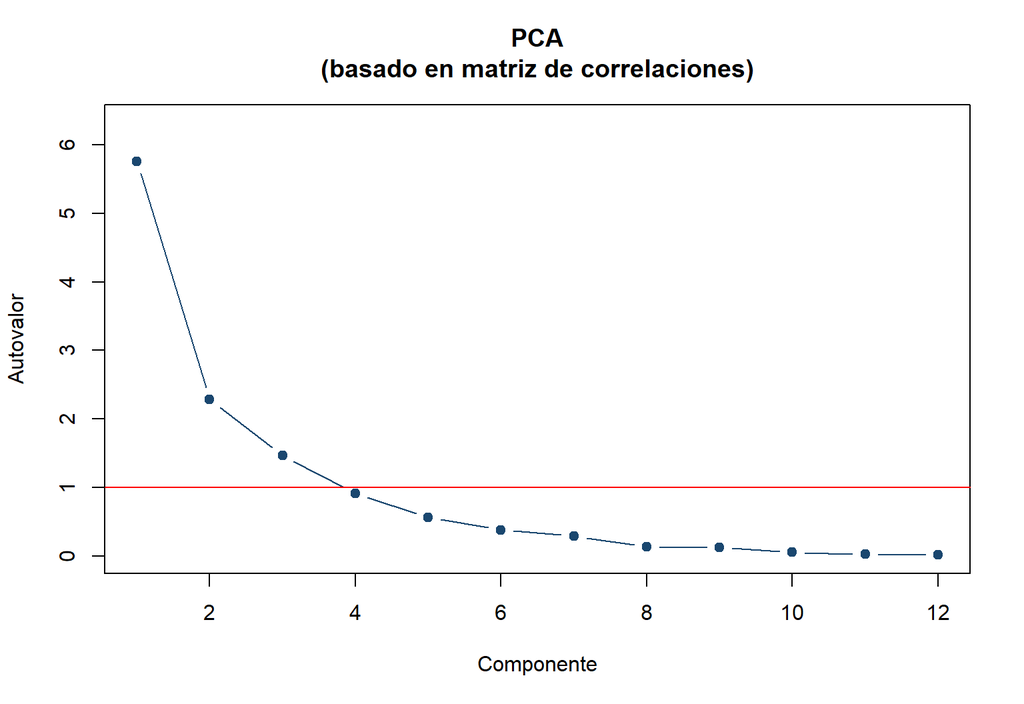

```r
screeplot_r(pc5$ev)
```

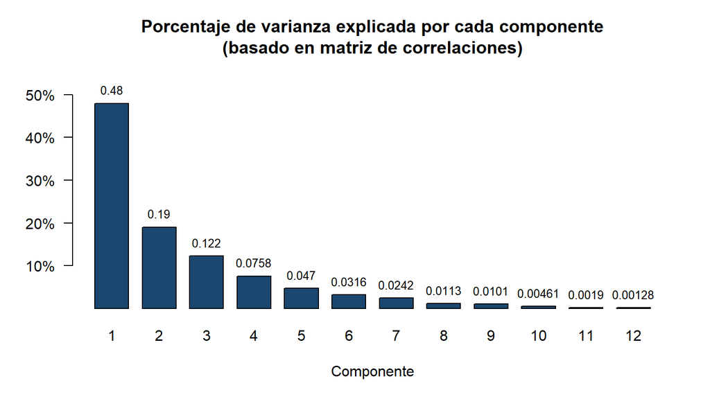

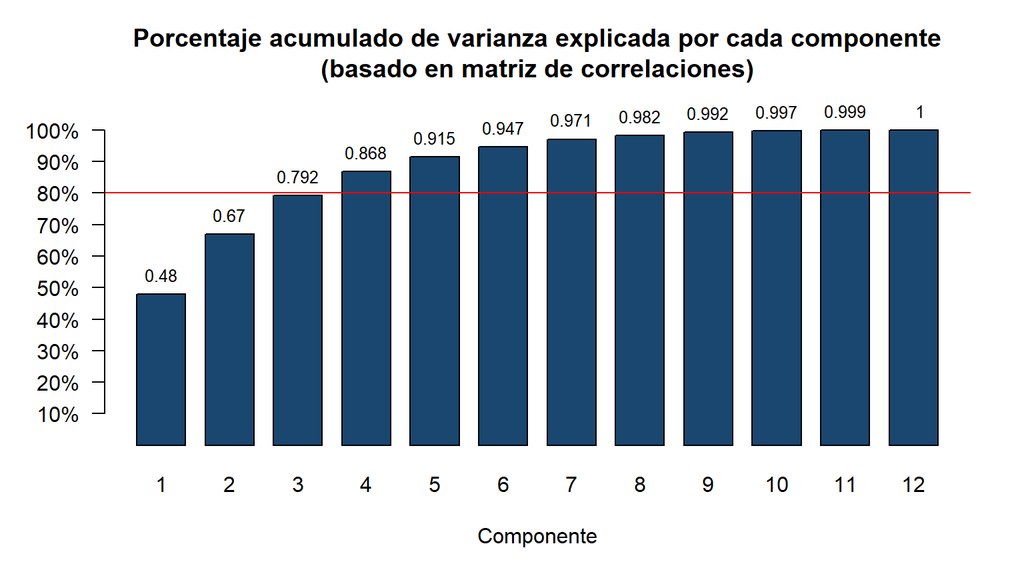

```r
barras_prop(pc5$ev, umbral = 0.8)
```

```r
acum5 <- cumsum(pc5$ev) / sum(pc5$ev)
```

Con el criterio del autovalor mayor a 1 se seleccionarían tres componentes, pero estos explican solo 79,23% de la varianza, por debajo del umbral del 80%; con el cuarto componente se alcanza 86,81%. Por lo tanto, se sugiere extraer los cuatro primeros componentes principales.

**Clasificación de las áreas metropolitanas según los dos primeros componentes.**

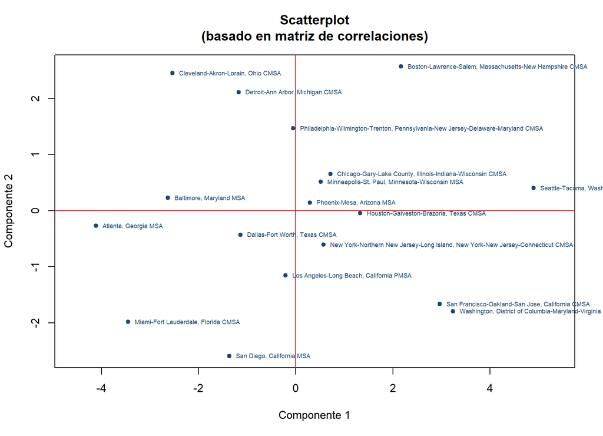

```r
sc5 <- scores_pca(X5, pc5)
scatter_pca(sc5, usa$meta, cex_lab = 0.55)
```

**Biplot (c = 0,5).**

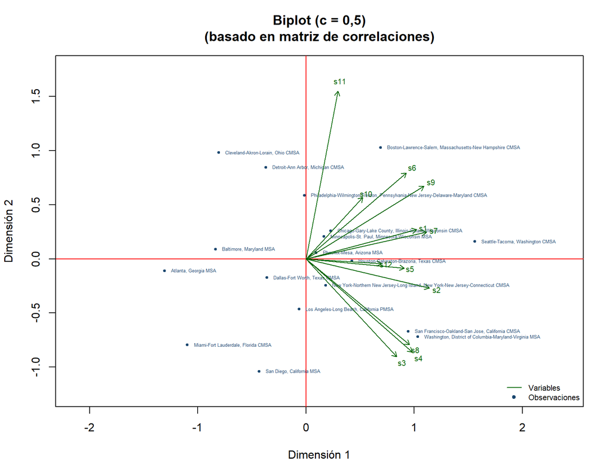

```r
biplot_r(X5, pc5, c = 0.5, dx = 1, dy = 2, etiquetas = usa$meta, cex_obs = 0.4)
```